# Crypto tests

Henrique

18/03/2021

Here is my small contribution. I´ve been working on backtesting different bot configurations to use on 3commas. I tried with the Tradingview scripts shared, but I was not confident with the results, so I decided to try to create my on backtest in R.

The starting strategy is one of the presented by TradeAlts in his videos (https://youtu.be/oil8FpMWs1E) and it uses the following parameters:

- Target Profit (TP): 1%
- Base Order (BO): 10.0 USD
- Safety Order (SO): 15.0 USD
- Price deviation to open safety orders (SOS): 2%
- Max safety trades count (MaxSO): 30
- Safety order volume scale (OS): 1.05
- Safety order step scale (MSC) 1.0

This configuration have a max value per bot of 1006 USD and cover a maximum of 60% of price deviation. Based on that and since I want to compare similar strategies, the following requirements were used for all setups tested:

- Maximum value per bot: 1500
- **Conservative** setups need to cover between 50% and 60% of price reduction
- **Moderate** setups need to cover between 30% and 40% of price reduction
- **Aggressive** setups need to cover less than 20% of price reduction
- All setups will use BO of 10 USD and SO of 15 or 20 USD (cause this is one of the things I want to test!)

**HOW IT WORKS**

I believe it´s important to describe the reasoning behind the script, cause it´s not easy to read and understand the code even if for me, who wrote it. It is also boring, so if you don´t care, just go to the next section.

- All simulations run with no stop.
- All deals start with a BO buying on close price and generating the setup table with all Safety Orders values and steps (the same table 3commas show when you create the bot)
- Every minute after that it checks if the high price is higher than the sell price in the table. If yes you have a sell, if no, it will test the low value.
- If the low value is lower than the SO prices, it buys the required quantity of SO (it will buy as many as required by the low price that minute)
- every minute it check again until you have a sell price. Them it starts a new deal buying at close price.
- The profit percentage was calculated based on the total value required for the bot, not in the total value spent in that deal.

As you can see, it is a simplified model, wrong as any model should be.

**RESULTS**

The data from the simulations shows some expected tendencies which (at least for me) enhance confidence in the results. e.g.:

- Setups with more safe orders closed more deals and more frequently. However, they require a larger amount of money allocated to run and it results in smaller profits, proportionally.
- The most profitable setups changed depending on the coins and periods. However, some setups shows positive results for all coins.

There is a lot to evaluate. Have a look in the aggregated results and share your thoughts! But remember:

*IT IS A SIMULATION ONLY. IT USES A MINUTE TIMEFRAME, AND THE RESULTS ARE NOT THE SAME AS IN REAL TIME.*

*Remember, also, that you should never assume that what happened in the past will repeat in the future!!*

The result table shows: - the setup tested (the acronyms are all above) - the total of deals closed - the average and the maximum duration of the deals, in minutes - the total of days with deals closed (from a total of 211 days in the simulation) - maximum of safe orders used in one deal - total allocated for the bot (that one calculated by 3 commas to never miss a SO) - final profit (USD) and profit percentage (final profit/total allocated) - Notes on the most profitable setups and the setups I (personally) want to test as more balanced.

*TEST ANY CONFIGURATION ON PAPERTRADING ACCOUNT BEFORE IF YOU WANT TO DO YOUR OWN TESTS!*

Also, remember that the results consider that you never reinvested any money in the bots and just cash out all profits. Is you reinvest or are profiting in crypto, your numbers should probably be much better!

*Change the SO between 15 and 20 USD*

| pair | TP | BO | SO | MaxSO | SOS | OS | MSC | tot_deals | avg_duration_m | max_duration_m | tot_days_deals | max_safe_orders | final_profit | required_investment | profit_percent |
| --- | --- | --- | --- | --- | --- | --- | --- | --- | --- | --- | --- | --- | --- | --- | --- |
| ADA/USDT | 1 | 10 | 15 | 30 | 2 | 1.05 | 1 | 1704 | 178.8762 | 9810 | 162 | 17 | 437.2857 | 1006.583 | 43.44260 |
| BTC/USDT | 1 | 10 | 15 | 30 | 2 | 1.05 | 1 | 524 | 582.4332 | 23269 | 136 | 13 | 367.7666 | 1006.583 | 36.53615 |
| BTT/USDT | 1 | 10 | 15 | 30 | 2 | 1.05 | 1 | 2024 | 150.8147 | 53431 | 114 | 24 | 548.2451 | 1006.583 | 54.46597 |
| ETH/USDT | 1 | 10 | 15 | 30 | 2 | 1.05 | 1 | 957 | 318.0846 | 9294 | 171 | 12 | 244.2755 | 1006.583 | 24.26781 |
| LINK/USDT | 1 | 10 | 15 | 30 | 2 | 1.05 | 1 | 1282 | 236.4633 | 12925 | 163 | 20 | 340.1770 | 1006.583 | 33.79524 |

Changes observed per pair

| pair | start_SO | compared_SO | Profit percent | Total profit | Days with deals | Budget |
| --- | --- | --- | --- | --- | --- | --- |
| ADA/USDT | 15 | 20 | -0.0491521 | 0.2596916 | 0.0383559 | 0.3248717 |
| BTC/USDT | 15 | 20 | -0.2037865 | 0.0548546 | 0.0318366 | 0.3248717 |
| BTT/USDT | 15 | 20 | -0.0266621 | 0.2894357 | 0.0765032 | 0.3248717 |
| ETH/USDT | 15 | 20 | -0.0673473 | 0.2355641 | 0.0270196 | 0.3248717 |
| LINK/USDT | 15 | 20 | -0.0403207 | 0.2713271 | 0.0436971 | 0.3248717 |
| All pairs | 15 | 20 | -0.0774538 | 0.2221746 | 0.0434825 | 0.3248717 |

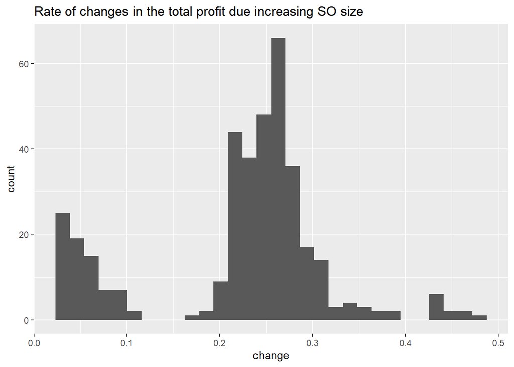

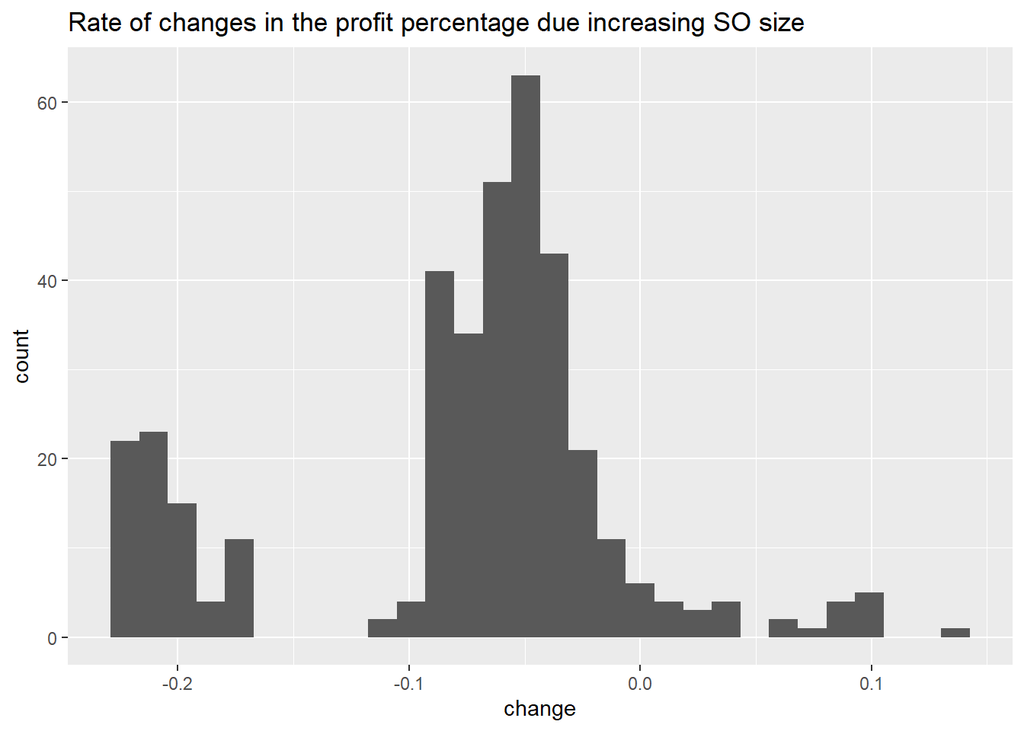

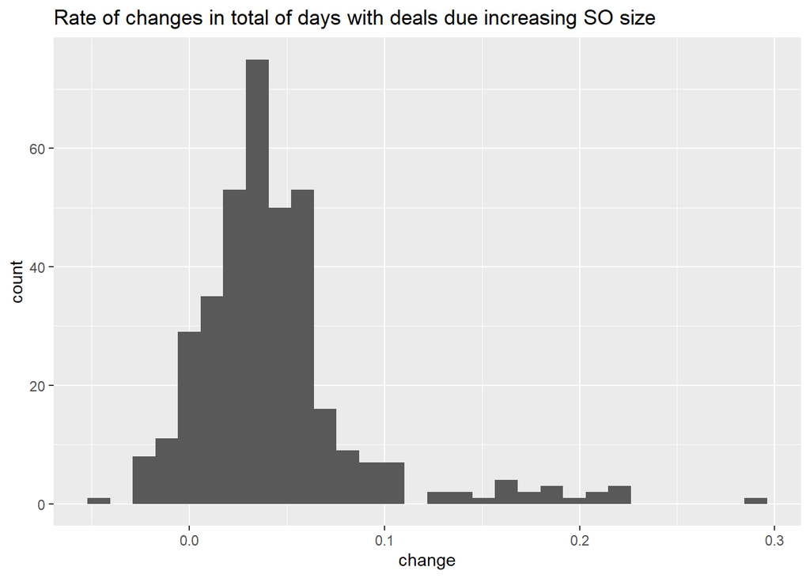

Changes observed per pair

| pair | start_TP | compared_TP | Profit percent | Total profit | Days with deals |
| --- | --- | --- | --- | --- | --- |
| ADA/USDT | 0.4 | 0.6 | 0.0988491 | 0.0988491 | -0.0338067 |
| ADA/USDT | 0.4 | 0.8 | 0.1554282 | 0.1554282 | -0.0896494 |
| ADA/USDT | 0.4 | 1.0 | 0.2269069 | 0.2269069 | -0.1262248 |
| ADA/USDT | 0.4 | 1.2 | 0.2878567 | 0.2878567 | -0.1570867 |
| ADA/USDT | 0.4 | 1.4 | 0.3169343 | 0.3169343 | -0.1984299 |
| BTC/USDT | 0.4 | 0.6 | 0.0490009 | 0.0490009 | -0.0623713 |
| BTC/USDT | 0.4 | 0.8 | 0.0838553 | 0.0838553 | -0.1184576 |
| BTC/USDT | 0.4 | 1.0 | 0.1377878 | 0.1377878 | -0.1487331 |
| BTC/USDT | 0.4 | 1.2 | 0.1555827 | 0.1555827 | -0.1932296 |
| BTC/USDT | 0.4 | 1.4 | 0.1956146 | 0.1956146 | -0.2187790 |
| BTT/USDT | 0.4 | 0.6 | 0.1010399 | 0.1010399 | -0.0497301 |
| BTT/USDT | 0.4 | 0.8 | 0.1824774 | 0.1824774 | -0.0963312 |
| BTT/USDT | 0.4 | 1.0 | 0.2432734 | 0.2432734 | -0.2094316 |
| BTT/USDT | 0.4 | 1.2 | 0.3059987 | 0.3059987 | -0.2430402 |
| BTT/USDT | 0.4 | 1.4 | 0.2888148 | 0.2888148 | -0.3032478 |
| ETH/USDT | 0.4 | 0.6 | 0.0817537 | 0.0817537 | -0.0442821 |
| ETH/USDT | 0.4 | 0.8 | 0.1479113 | 0.1479113 | -0.0683878 |
| ETH/USDT | 0.4 | 1.0 | 0.1989309 | 0.1989309 | -0.1053314 |
| ETH/USDT | 0.4 | 1.2 | 0.2303597 | 0.2303597 | -0.1604929 |
| ETH/USDT | 0.4 | 1.4 | 0.2819904 | 0.2819904 | -0.1662553 |
| LINK/USDT | 0.4 | 0.6 | 0.0767853 | 0.0767853 | -0.0460334 |
| LINK/USDT | 0.4 | 0.8 | 0.1475152 | 0.1475152 | -0.0677051 |
| LINK/USDT | 0.4 | 1.0 | 0.2001490 | 0.2001490 | -0.1198353 |
| LINK/USDT | 0.4 | 1.2 | 0.2664815 | 0.2664815 | -0.1370780 |
| LINK/USDT | 0.4 | 1.4 | 0.3195087 | 0.3195087 | -0.1629861 |
| All pairs | 0.4 | 0.6 | 0.0814858 | 0.0814858 | -0.0472447 |
| All pairs | 0.4 | 0.8 | 0.1434375 | 0.1434375 | -0.0881062 |
| All pairs | 0.4 | 1.0 | 0.2014096 | 0.2014096 | -0.1419112 |
| All pairs | 0.4 | 1.2 | 0.2492559 | 0.2492559 | -0.1781855 |
| All pairs | 0.4 | 1.4 | 0.2805726 | 0.2805726 | -0.2099396 |

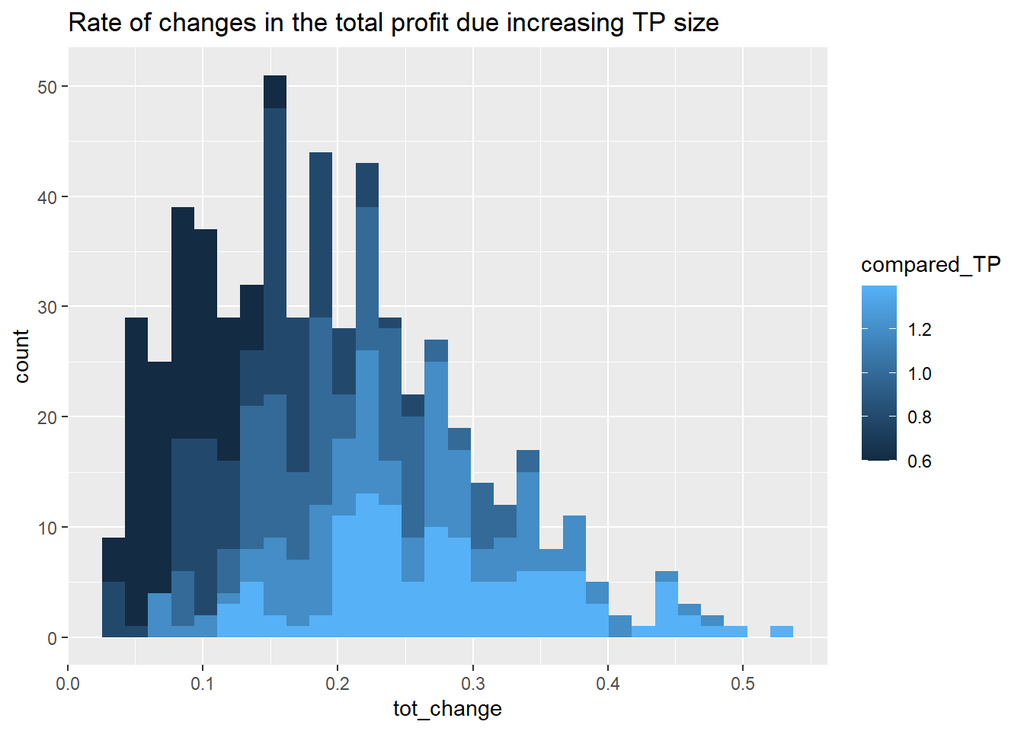

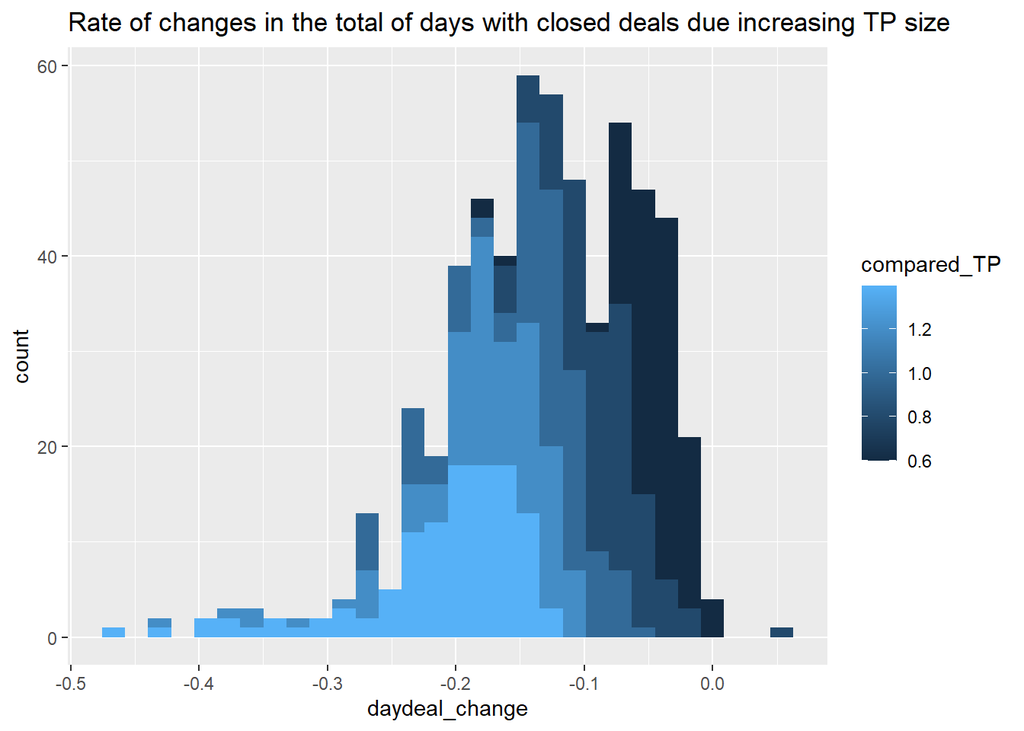

Changes observed per pair

| pair | start_MaxSO | compared_MaxSO | Profit percent | Total profit | Days with deals | Budget |
| --- | --- | --- | --- | --- | --- | --- |
| ADA/USDT | 15 | 20 | -0.3389492 | 0.0040971 | 0.0019411 | 0.5424689 |
| ADA/USDT | 15 | 22 | -0.5511648 | 0.0000000 | 0.0000000 | 1.2279895 |
| ADA/USDT | 15 | 25 | -0.6704724 | 0.0058141 | 0.0020430 | 2.0522912 |
| ADA/USDT | 15 | 30 | -0.5779616 | 0.0046921 | 0.0024010 | 1.4934154 |
| BTC/USDT | 15 | 20 | -0.3416943 | 0.0000000 | 0.0000000 | 0.5424689 |
| BTC/USDT | 15 | 22 | -0.5511648 | 0.0000000 | 0.0000000 | 1.2279895 |
| BTC/USDT | 15 | 25 | -0.6723773 | 0.0000000 | 0.0000000 | 2.0522912 |
| BTC/USDT | 15 | 30 | -0.5799014 | 0.0000000 | 0.0000000 | 1.4934154 |
| BTT/USDT | 15 | 20 | -0.3097871 | 0.0481009 | 0.0000000 | 0.5424689 |
| BTT/USDT | 15 | 22 | -0.5116782 | 0.0879758 | 0.0482653 | 1.2279895 |
| BTT/USDT | 15 | 25 | -0.6358840 | 0.1113881 | 0.0604868 | 2.0522912 |
| BTT/USDT | 15 | 30 | -0.5461552 | 0.0832048 | 0.0316667 | 1.4934154 |
| ETH/USDT | 15 | 20 | -0.3416943 | 0.0000000 | 0.0000000 | 0.5424689 |
| ETH/USDT | 15 | 22 | -0.5511648 | 0.0000000 | 0.0000000 | 1.2279895 |
| ETH/USDT | 15 | 25 | -0.6723773 | 0.0000000 | 0.0000000 | 2.0522912 |
| ETH/USDT | 15 | 30 | -0.5799014 | 0.0000000 | 0.0000000 | 1.4934154 |
| LINK/USDT | 15 | 20 | -0.3293268 | 0.0188532 | 0.0015240 | 0.5424689 |
| LINK/USDT | 15 | 22 | -0.5433080 | 0.0175049 | 0.0000000 | 1.2279895 |
| LINK/USDT | 15 | 25 | -0.6662175 | 0.0188013 | 0.0000000 | 2.0522912 |
| LINK/USDT | 15 | 30 | -0.5719796 | 0.0193377 | 0.0022860 | 1.4934154 |
| All pairs | 15 | 20 | -0.3322903 | 0.0142102 | 0.0006930 | 0.5424689 |
| All pairs | 15 | 22 | -0.5416962 | 0.0210961 | 0.0096531 | 1.2279895 |
| All pairs | 15 | 25 | -0.6634657 | 0.0272007 | 0.0125060 | 2.0522912 |
| All pairs | 15 | 30 | -0.5711798 | 0.0214469 | 0.0072707 | 1.4934154 |

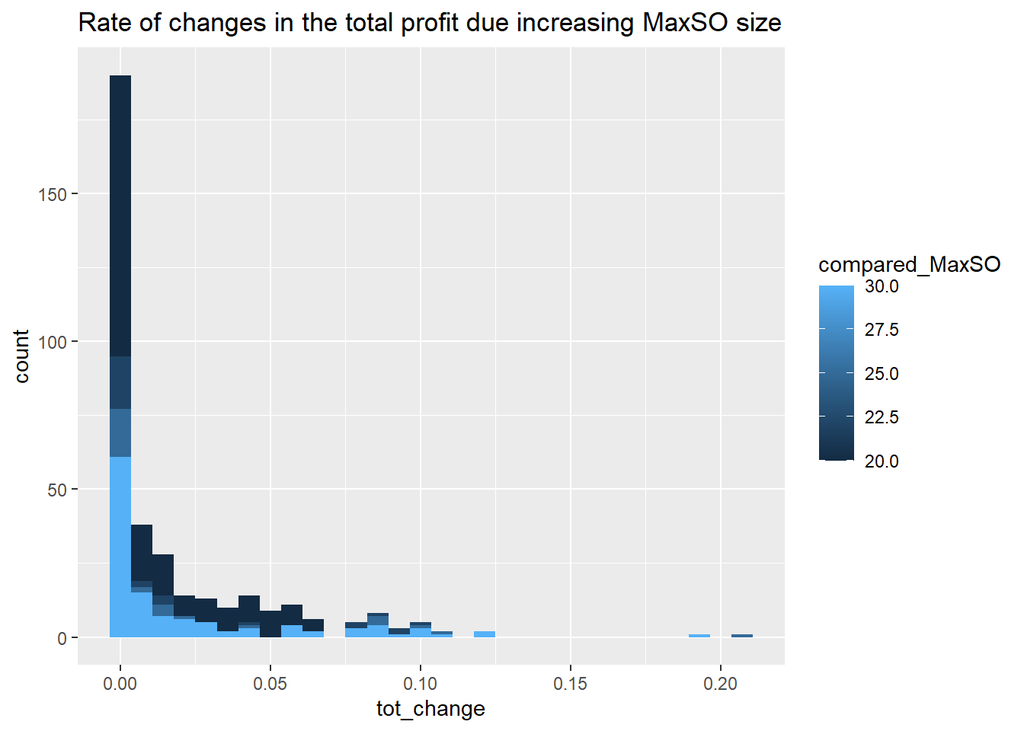

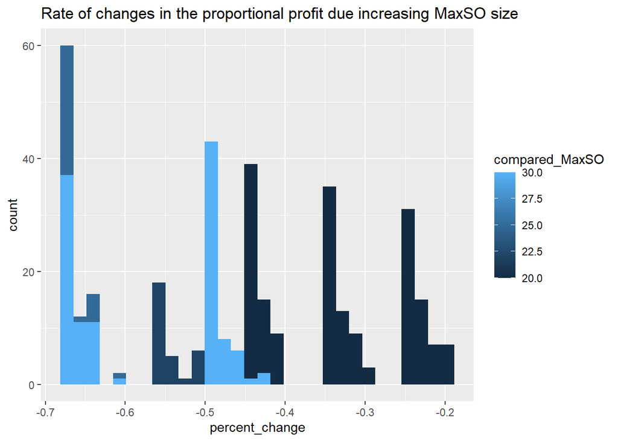

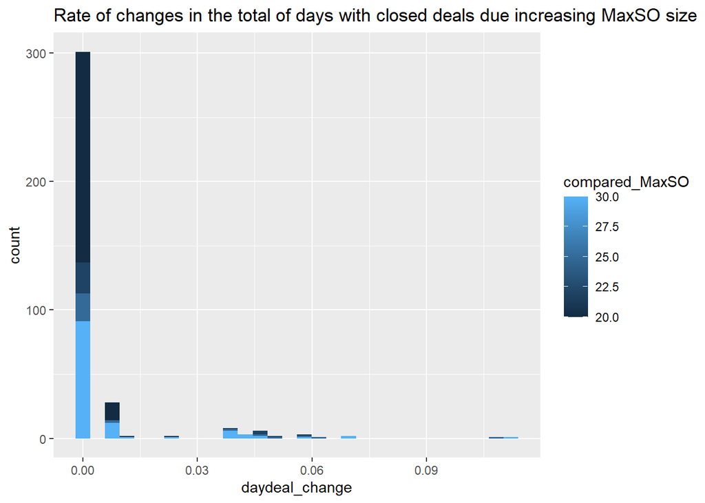

Changes observed per pair

| pair | start_SOS | compared_SOS | Profit percent | Total profit | Days with deals | Budget |
| --- | --- | --- | --- | --- | --- | --- |
| ADA/USDT | 0.3 | 0.4 | -0.1804593 | 0.0473037 | 0.1074691 | 0.3125443 |
| ADA/USDT | 0.3 | 0.5 | -0.0155655 | -0.0155655 | 0.3253938 | 0.0000000 |
| ADA/USDT | 0.3 | 2.0 | -0.7278385 | -0.1940309 | 0.8364587 | 2.5659405 |
| ADA/USDT | 0.3 | 2.4 | -0.8110702 | -0.3065601 | 0.8329787 | 2.6707706 |
| BTC/USDT | 0.3 | 0.4 | -0.1859447 | 0.0359647 | 0.0804255 | 0.3125443 |
| BTC/USDT | 0.3 | 0.5 | -0.0944882 | -0.0944882 | 0.1239106 | 0.0000000 |
| BTC/USDT | 0.3 | 2.0 | -0.7320079 | -0.2093610 | 0.5645297 | 2.5659405 |
| BTC/USDT | 0.3 | 2.4 | -0.8209808 | -0.3429341 | 0.4280158 | 2.6707706 |
| BTT/USDT | 0.3 | 0.4 | -0.1499195 | 0.1021774 | 0.1467787 | 0.3125443 |
| BTT/USDT | 0.3 | 0.5 | 0.1156663 | 0.1156663 | 0.3626050 | 0.0000000 |
| BTT/USDT | 0.3 | 2.0 | -0.4817064 | 0.5707908 | 2.6044118 | 2.5659405 |
| BTT/USDT | 0.3 | 2.4 | -0.6080227 | 0.4388326 | 3.1764706 | 2.6707706 |
| ETH/USDT | 0.3 | 0.4 | -0.2084928 | 0.0207136 | 0.0585164 | 0.3125443 |
| ETH/USDT | 0.3 | 0.5 | -0.0972807 | -0.0972807 | 0.1342279 | 0.0000000 |
| ETH/USDT | 0.3 | 2.0 | -0.7659201 | -0.2998892 | 0.5844210 | 2.5659405 |
| ETH/USDT | 0.3 | 2.4 | -0.8380595 | -0.4056307 | 0.5439602 | 2.6707706 |
| LINK/USDT | 0.3 | 0.4 | -0.0340767 | 0.2583475 | 0.2821342 | 0.3125443 |
| LINK/USDT | 0.3 | 0.5 | -0.0161213 | -0.0161213 | 0.1561080 | 0.0000000 |
| LINK/USDT | 0.3 | 2.0 | -0.6847825 | -0.0258673 | 1.1035470 | 2.5659405 |
| LINK/USDT | 0.3 | 2.4 | -0.7604479 | -0.1209217 | 1.2256863 | 2.6707706 |
| All pairs | 0.3 | 0.4 | -0.1517786 | 0.0929014 | 0.1350648 | 0.3125443 |
| All pairs | 0.3 | 0.5 | -0.0215579 | -0.0215579 | 0.2204491 | 0.0000000 |
| All pairs | 0.3 | 2.0 | -0.6784511 | -0.0316715 | 1.1386736 | 2.5659405 |
| All pairs | 0.3 | 2.4 | -0.7677162 | -0.1474428 | 1.2414223 | 2.6707706 |

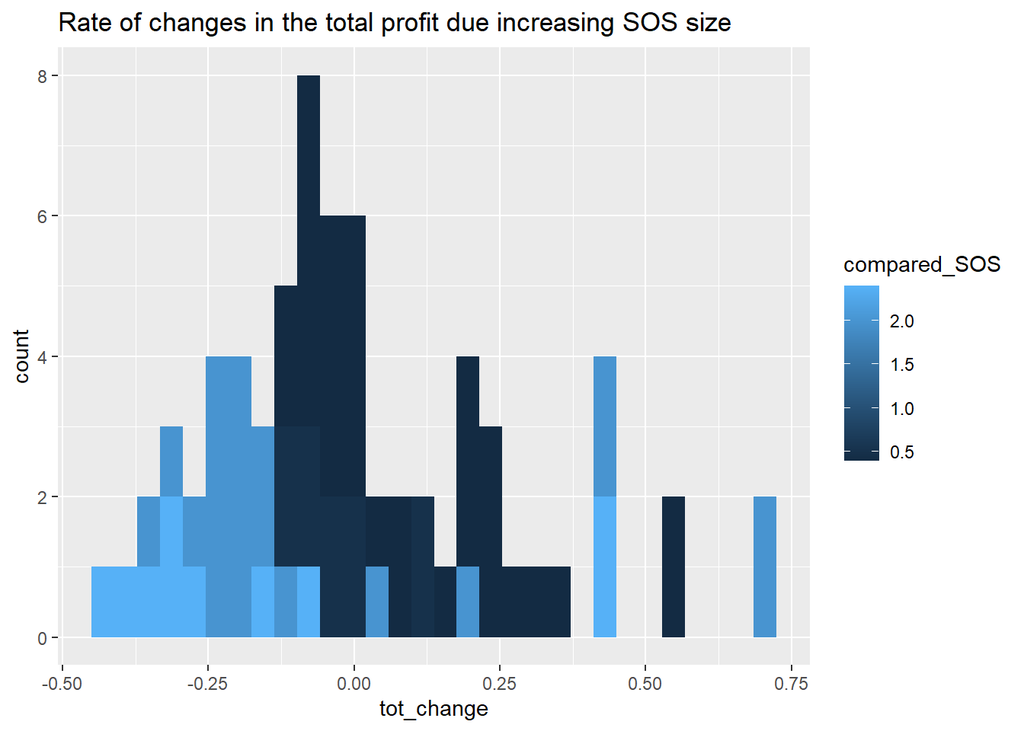

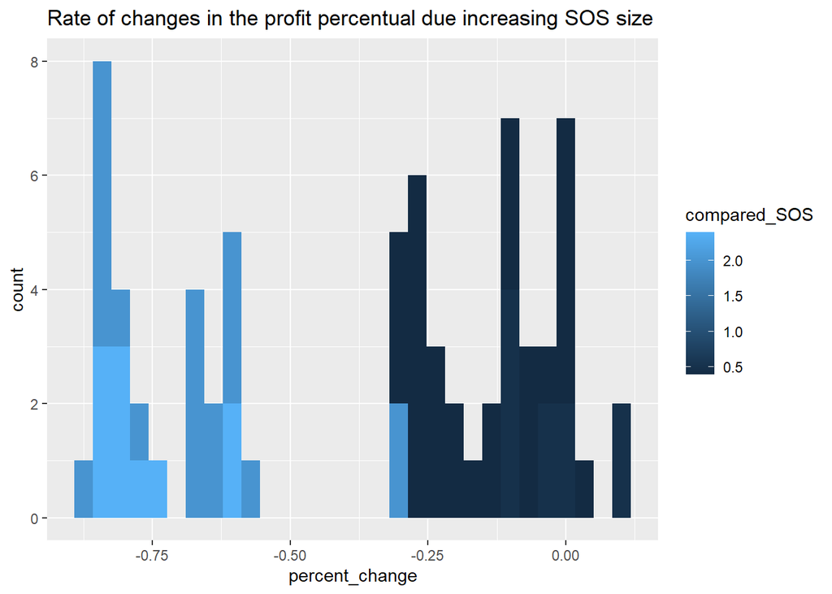

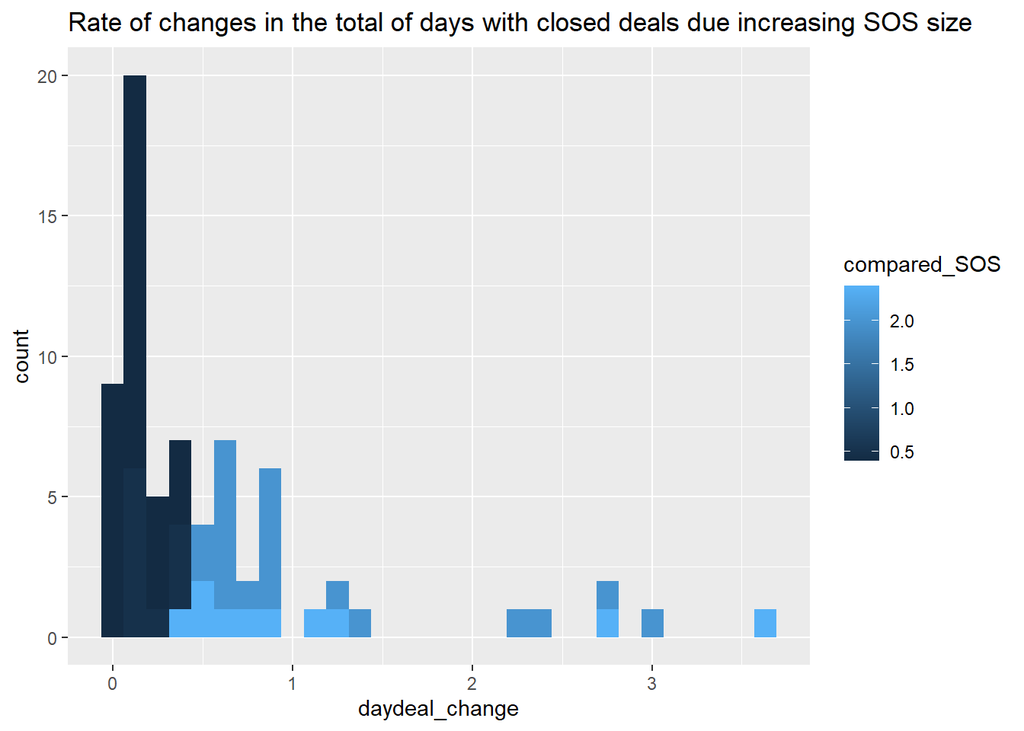

Changes observed per pair

| pair | start_OS | compared_OS | Profit percent | Total profit | Days with deals | Budget |
| --- | --- | --- | --- | --- | --- | --- |
| ADA/USDT | 1 | 1.05 | -0.3664749 | 0.1011660 | 0.0407537 | 0.7841986 |
| ADA/USDT | 1 | 1.10 | -0.5604003 | 0.1995852 | 0.0675917 | 1.9181057 |
| BTC/USDT | 1 | 1.05 | -0.4210328 | 0.0065043 | 0.0066766 | 0.7841986 |
| BTC/USDT | 1 | 1.10 | -0.6217310 | 0.0340435 | 0.0257892 | 1.9181057 |
| BTT/USDT | 1 | 1.05 | -0.3070527 | 0.2067173 | 0.1780870 | 0.7841986 |
| BTT/USDT | 1 | 1.10 | -0.5013153 | 0.3688386 | 0.2885573 | 1.9181057 |
| ETH/USDT | 1 | 1.05 | -0.3650043 | 0.1035272 | 0.0303009 | 0.7841986 |
| ETH/USDT | 1 | 1.10 | -0.5641953 | 0.1903575 | 0.0454974 | 1.9181057 |
| LINK/USDT | 1 | 1.05 | -0.3473009 | 0.1346315 | 0.0616879 | 0.7841986 |
| LINK/USDT | 1 | 1.10 | -0.5376041 | 0.2614879 | 0.0950377 | 1.9181057 |
| All pairs | 1 | 1.05 | -0.3613731 | 0.1105093 | 0.0635012 | 0.7841986 |
| All pairs | 1 | 1.10 | -0.5570492 | 0.2108626 | 0.1044947 | 1.9181057 |

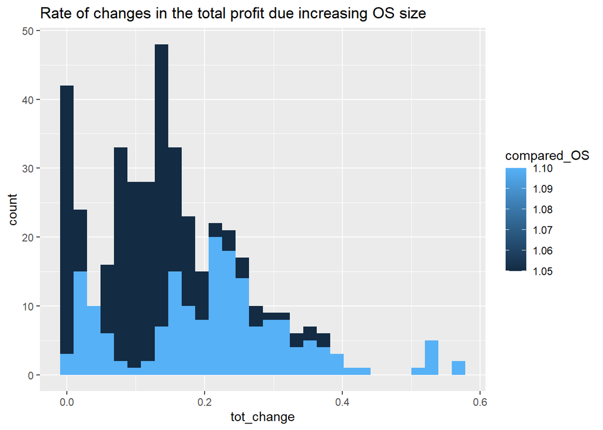

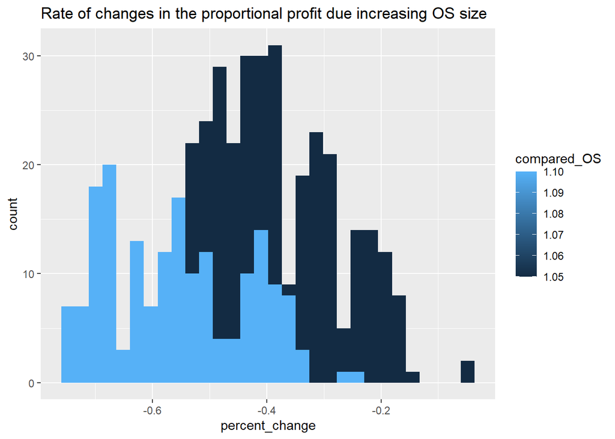

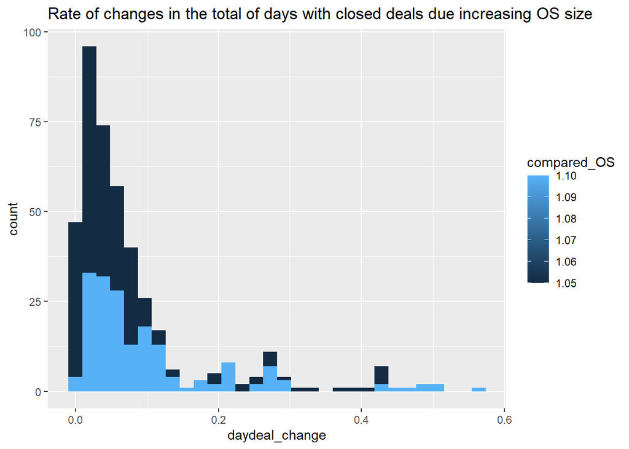

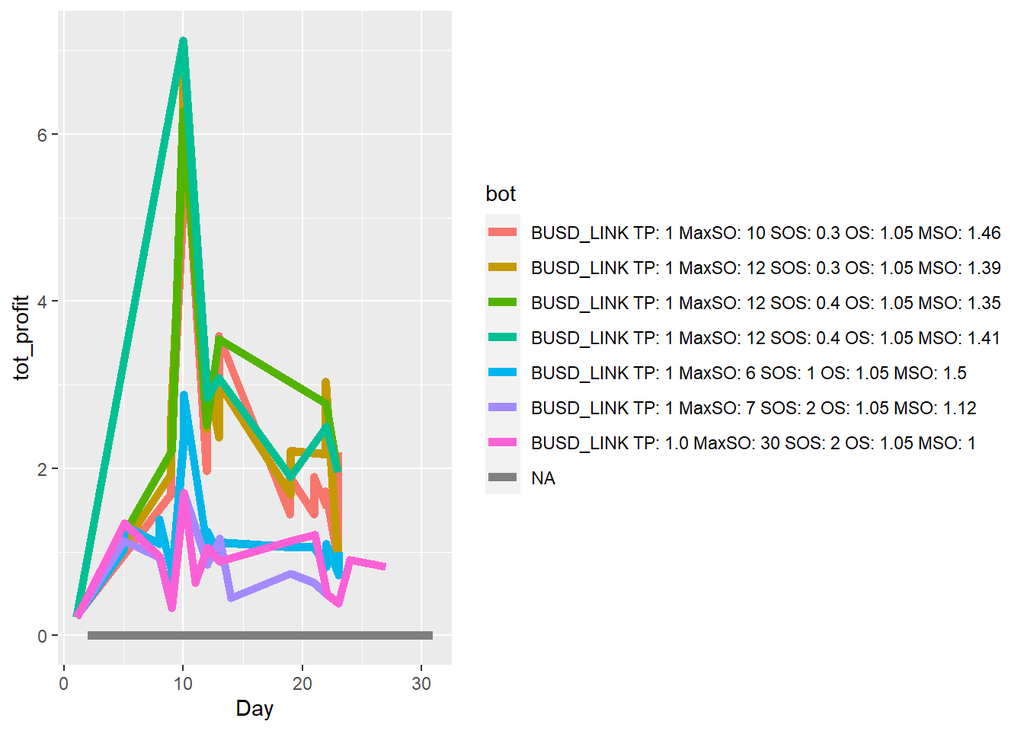

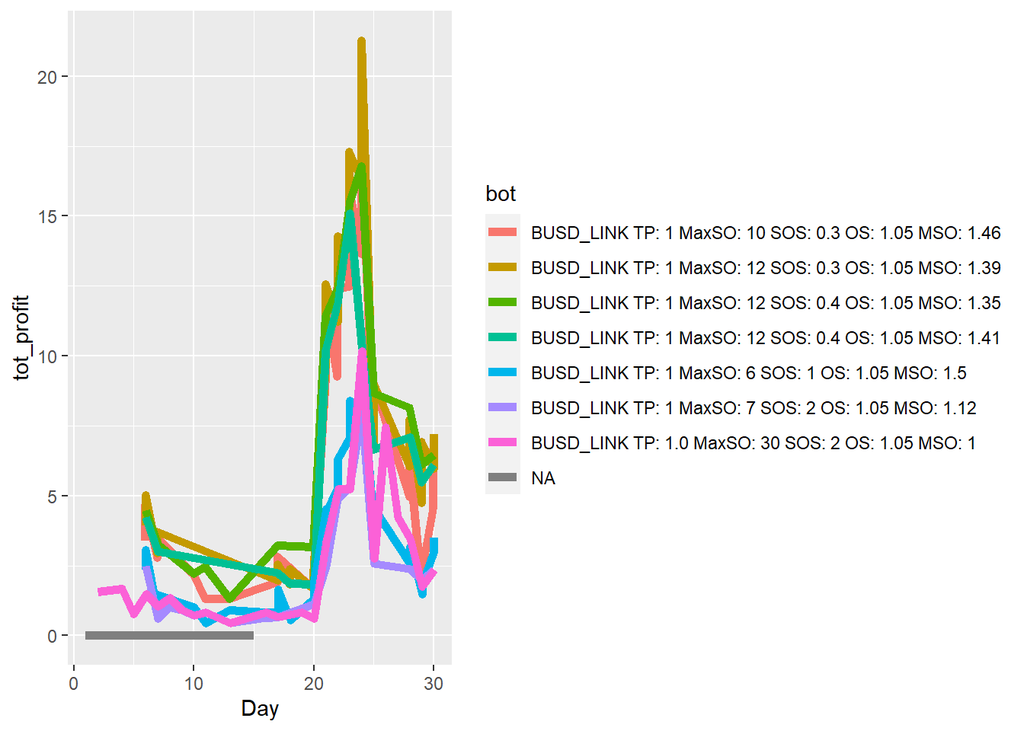

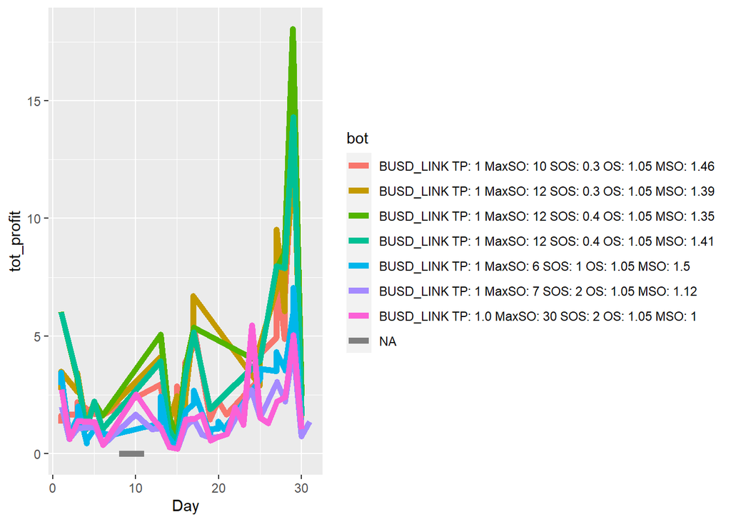

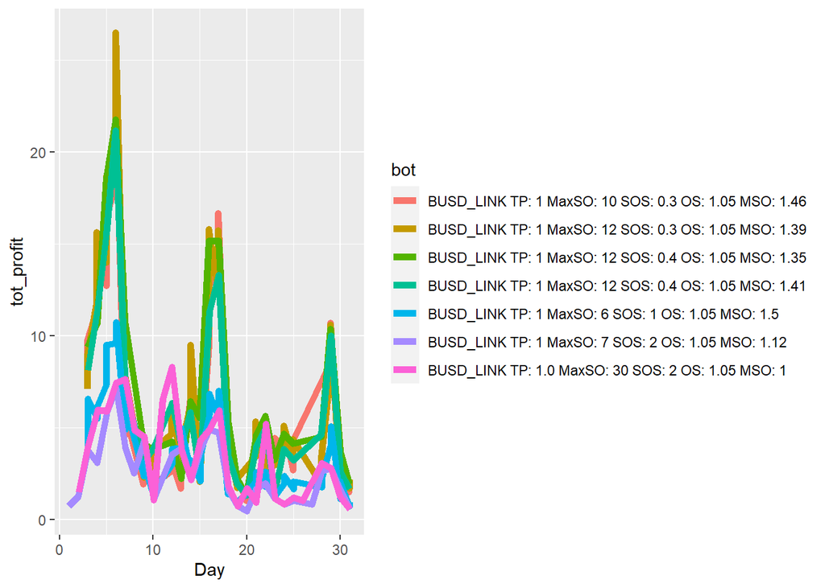

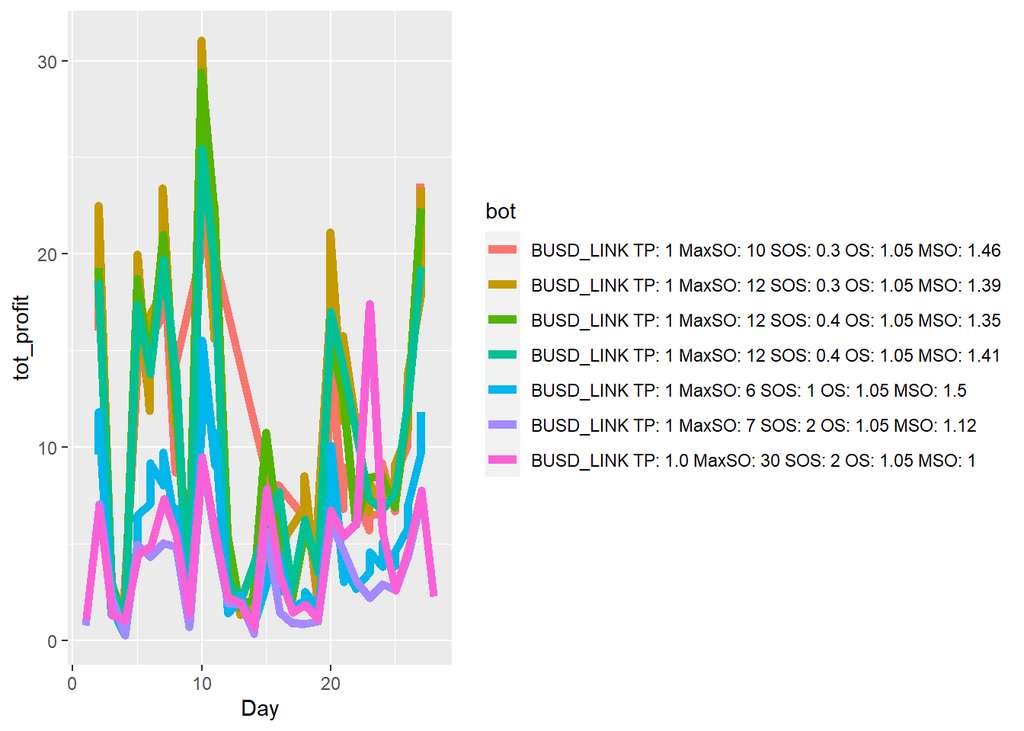

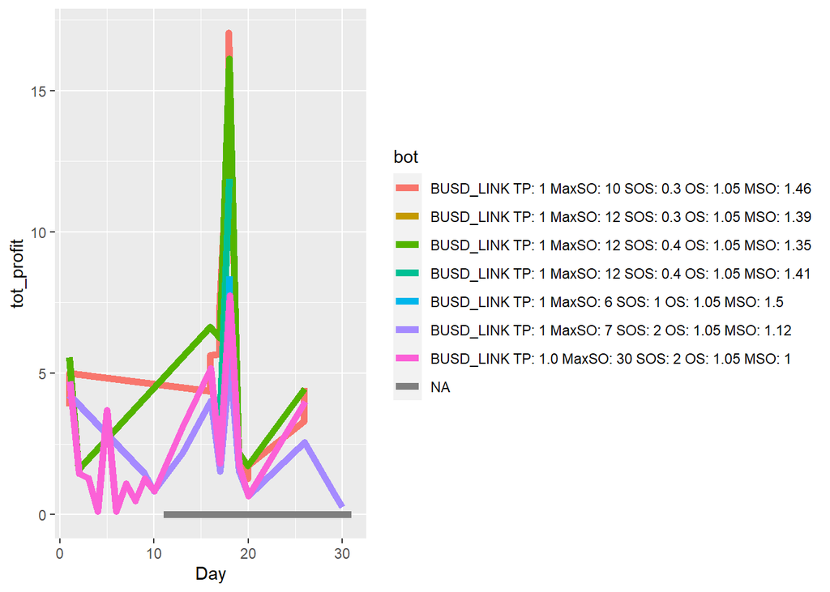

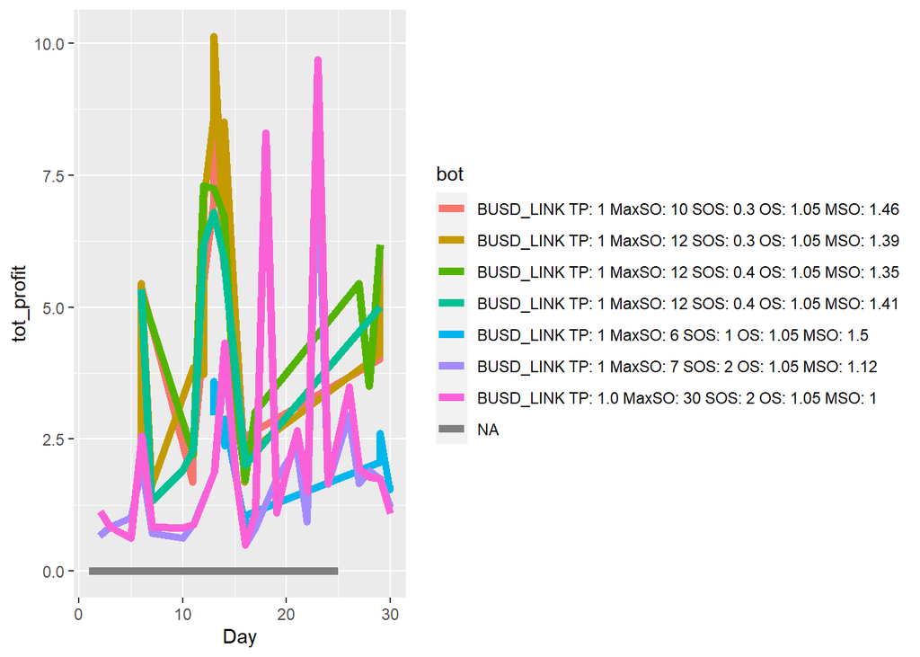

| pair | TP | BO | SO | MaxSO | SOS | OS | MSC | end_date | tot_deals | avg_duration_m | max_duration_m | tot_days_deals | max_safe_orders | final_profit | required_investment | profit_percent |
| --- | --- | --- | --- | --- | --- | --- | --- | --- | --- | --- | --- | --- | --- | --- | --- | --- |
| BTC-USDT | 1.0 | 10 | 15 | 30 | 2.0 | 1.05 | 1.00 | 2020-09-29 23:11:00 | 2150 | 733.2330 | 243268 | 394 | 30 | 766.5396 | 1006.5827 | 0.7615267 |
| BTC-USDT | 1.0 | 10 | 15 | 20 | 2.0 | 1.05 | 1.00 | 2020-09-29 23:11:00 | 1867 | 844.3765 | 288121 | 341 | 20 | 668.3727 | 505.9893 | 1.3209226 |
| BTC-USDT | 1.0 | 10 | 15 | 15 | 2.0 | 1.05 | 1.00 | 2020-09-29 23:11:00 | 1739 | 906.5273 | 297839 | 324 | 15 | 623.3562 | 333.6785 | 1.8681343 |
| BTC-USDT | 0.4 | 10 | 20 | 15 | 2.0 | 1.00 | 1.00 | 2020-09-29 23:11:00 | 4766 | 330.7702 | 298133 | 388 | 15 | 568.7284 | 310.0000 | 1.8346076 |
| BTC-USDT | 1.0 | 10 | 15 | 6 | 0.4 | 1.05 | 1.90 | 2017-12-18 12:12:00 | 307 | 367.2704 | 11834 | 51 | 6 | 138.9180 | 112.0287 | 1.2400215 |
| BTC-USDT | 1.0 | 10 | 15 | 7 | 2.0 | 1.05 | 1.12 | 2020-09-01 16:00:00 | 966 | 1589.7516 | 681498 | 191 | 7 | 307.7264 | 132.1301 | 2.3289650 |
| BTC-USDT | 1.0 | 10 | 15 | 6 | 1.0 | 1.05 | 1.50 | 2018-01-06 22:27:00 | 447 | 314.8255 | 9437 | 67 | 6 | 159.3589 | 112.0287 | 1.4224825 |

Time difference of -1094.758 days [1] 0.2126849 [1] 0.06954338